# Caso 02

recursos compartidos: préstamo de 1 operario en 2–4 (2 sem. de retraso) frente a 3–5

# Enunciado

Usted dirige un proyecto de instalaciones cuyo cuadro de prelaciones, duraciones (semanas) y operarios necesarios por actividad se adjunta. La empresa le ha asignado una cuadrilla fija de **12 operarios**, dimensionada justo para el pico de carga del plan de inicios más tempranos. El contrato con el cliente fija la entrega en la semana 16 con una penalización de **4 k€ por semana** de retraso. El proyecto empieza el lunes que viene (semana 1). El viernes recibe estos mensajes.

Tabla 1: Plan del proyecto

| activity | predecessor | duration | resources |
| --- | --- | --- | --- |
| A | --- | 2 | 4 |
| B | --- | 2 | 4 |
| C | --- | 4 | 4 |
| D | A,C | 4 | 4 |
| E | A,B | 2 | 3 |
| F | C,E | 6 | 2 |
| G | F | 6 | 1 |
| H | D | 6 | 1 |

> **De: Jefa del proyecto Delta** Tengo un problema serio: necesito **1 operario de tu cuadrilla durante las semanas 2 a 4** (ambas incluidas) para un trabajo que no puedo retrasar. Antes de la semana 2 no me sirven. Si no los tengo, mi proyecto se retrasa esas 3 semanas y la penalización de mi cliente es de 8 k€ por semana; cada semana que tarden en llegar a partir de entonces es una semana de retraso para mí. ¿Me los puedes dejar?

> **De: Director de operaciones** Lo del proyecto Delta es prioritario para la empresa: es un cliente estratégico y la penalización es alta. Entiendo que tu proyecto también tiene plazo. Dime cuánto te cuesta prestarlos y busquemos la opción más barata para la empresa en conjunto, no para cada proyecto por separado.

> **De: Cliente** Les recordamos que la fecha de entrega (semana 16) está ligada a la apertura de nuestras instalaciones y no es negociable. La penalización de 4 k€ por semana se aplicará desde el primer día de retraso.

> **De: Jefe de obra** He mirado el plan. En la semana 2 vamos al máximo de gente y la ventana que pide Delta la pisa; si nos quitan 1 operario ahí, algo se retrasa. En cambio, a partir de la semana 3 tenemos más margen: ahí podríamos prestarlos sin que el plazo se mueva, si a Delta le vale.

> **De: Recursos humanos** Podemos subcontratar operarios a 2.0 k€ por operario y semana, pero necesitamos **una semana de preaviso** para tenerlos en obra: como muy pronto, el lunes de la semana 2. Decidid pronto.

Responda a las preguntas siguientes **antes** de decidir. En la penúltima se le pide la decisión y cómo la comunicaría a cada uno de los implicados (jefa del proyecto Delta, director de operaciones, cliente, jefe de obra, recursos humanos).

1. Dibuje el Gantt de inicios más tempranos con las cargas y el diagrama de cargas. ¿En qué semanas se alcanza el máximo de 12 operarios y qué actividades coinciden en ellas? ¿Cuáles son críticas?

2. Simule el préstamo de 1 operario en las semanas 2–4 con un planificador en paralelo (como Wiest-Levy) con un límite de recursos por periodo (12 fuera de la ventana, 11 dentro). ¿Qué actividades esperan, cuánto se alarga el proyecto y cuánto cuesta en penalizaciones?

3. Repita la simulación para todas las ventanas posibles de 3 semanas consecutivas. ¿En cuáles se puede prestar sin retrasar el proyecto? Explique el resultado a partir de las cargas y las holguras. ¿Tiene razón el jefe de obra?

4. Construya la tabla de opciones (negarse, prestar como se pide, prestar en la ventana del jefe de obra, subcontratar) con el coste de cada una para su proyecto, para el proyecto Delta y para la empresa. ¿Qué opción minimiza el coste de la empresa? ¿Coincide con la que minimiza el de su proyecto?

5. Tome una decisión y redacte en tres o cuatro líneas el mensaje de respuesta a cada implicado.

6. ¿Qué fallo de organización revela el caso y cómo se evitaría la próxima vez (reparto de recursos entre proyectos, reservas, prioridades)?

# Resolución

El préstamo es un límite de recursos *por periodo*. El algoritmo de asignación de la librería (`asignar`, Wiest-Levy) no interrumpe actividades en curso, así que cuando el límite baja a mitad de una actividad no puede respetarlo; se usa aquí un planificador en paralelo equivalente que sólo deja empezar una actividad si cabe en todas las semanas que va a ocupar.

## Apartado 1

1. Dibuje el Gantt de inicios más tempranos con las cargas y el diagrama de cargas. ¿En qué semanas se alcanza el máximo de 12 operarios y qué actividades coinciden en ellas? ¿Cuáles son críticas?

[figure not shown]

Figura 1: Gantt de inicios más tempranos con los operarios de cada actividad; fila Total, carga por semana

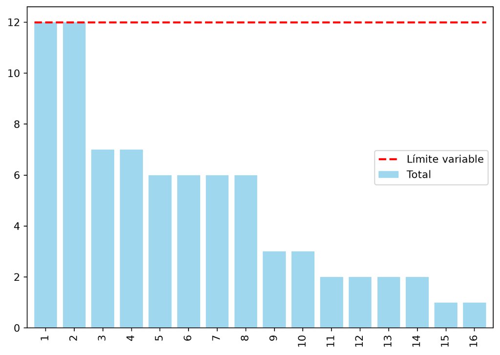

Figura 2: Diagrama de cargas con la cuadrilla disponible

[figure not shown]

ninguna celda (0 de 64)

[figure not shown]

Haz clic en un número de la tabla para ver cómo se calcula.

👆 **Interactivo:** haz clic en cualquier celda de la tabla para ver cómo se calcula (otro clic la deselecciona), o usa los botones y las flechas del teclado.

| Actividad | Duración | Inicio más temprano | Fin más temprano | Inicio más tardío | Fin más tardío | H total | H libre | H independiente |
| --- | --- | --- | --- | --- | --- | --- | --- | --- |
| A | 2 | 0 | 2 | 0 | 2 | 0 | 0 | 0 |
| B | 2 | 0 | 2 | 0 | 2 | 0 | 0 | 0 |
| C | 4 | 0 | 4 | 0 | 4 | 0 | 0 | 0 |
| D | 4 | 4 | 8 | 6 | 10 | 2 | 0 | 0 |
| E | 2 | 2 | 4 | 2 | 4 | 0 | 0 | 0 |
| F | 6 | 4 | 10 | 4 | 10 | 0 | 0 | 0 |
| G | 6 | 10 | 16 | 10 | 16 | 0 | 0 | 0 |
| H | 6 | 8 | 14 | 10 | 16 | 2 | 2 | 0 |

**Respuesta:** el plan de inicios más tempranos llega al máximo de 12 operarios en las semanas 1 y 2; en todas coinciden A, B y C. Las actividades críticas (holgura total 0) son A, B, C, E, F y G. La ventana que pide Delta (2–4) incluye la semana de pico 2. Prestar 1 operario en una semana en la que la carga supera 11 obliga a aplazar alguna actividad; que eso retrase el proyecto depende de si la actividad aplazada tiene holgura suficiente (y de si al aplazarla arrastra a otras hasta agotar la suya).

## Apartado 2

2. Simule el préstamo de 1 operario en las semanas 2–4 con un planificador en paralelo (como Wiest-Levy) con un límite de recursos por periodo (12 fuera de la ventana, 11 dentro). ¿Qué actividades esperan, cuánto se alarga el proyecto y cuánto cuesta en penalizaciones?

[figure not shown]

Figura 3: Programación con 11 operarios en las semanas 2–4 y 12 en las demás (fila Máximo); las filas 💤 son las esperas

El planificador recorre las semanas; al principio de cada una ordena las actividades disponibles (predecesoras terminadas) por holgura total, de menor a mayor (en caso de empate, por orden alfabético), y deja empezar cada una si cabe en el límite de todas las semanas que ocuparía (11 dentro de la ventana 2–4, 12 fuera). Cada vez que una actividad disponible no cabe, se anota la primera semana en la que se pasaría del límite:

Tabla 2: Esperas con el préstamo pedido: por qué no cabe cada actividad

| semana en que podría empezar | actividad | operarios | semanas que ocuparía | primera semana sin sitio | carga ya asignada + operarios > límite |
| --- | --- | --- | --- | --- | --- |
| 1 | C | 4 | 1–4 | 2 | 8 + 4 = 12 > 11 |
| 2 | C | 4 | 2–5 | 2 | 8 + 4 = 12 > 11 |

- C espera 2 semanas y tenía holgura total 0.

**Respuesta:** con el préstamo en las semanas 2–4 espera C; el proyecto pasa de 16 a **18 semanas** (C es crítica: su espera pasa entera al plazo): 2 semanas de retraso y 4 × 2 = **8 k€** de penalización.

## Apartado 3

3. Repita la simulación para todas las ventanas posibles de 3 semanas consecutivas. ¿En cuáles se puede prestar sin retrasar el proyecto? Explique el resultado a partir de las cargas y las holguras. ¿Tiene razón el jefe de obra?

Tabla 3: Duración del proyecto según la ventana del préstamo

| semanas | carga antes del préstamo | duración | retraso | explicación |
| --- | --- | --- | --- | --- |
| 1–3 | 12, 12, 7 | 18 | 2 | carga máxima 12 > 11; esperan C (2 sem.; holgura 0): no basta la holgura |
| 2–4 | 12, 7, 7 | 18 | 2 | carga máxima 12 > 11; esperan C (2 sem.; holgura 0): no basta la holgura |
| 3–5 | 7, 7, 6 | 16 | 0 | carga máxima 7 ≤ 11: no hay que aplazar nada |
| 4–6 | 7, 6, 6 | 16 | 0 | carga máxima 7 ≤ 11: no hay que aplazar nada |
| 5–7 | 6, 6, 6 | 16 | 0 | carga máxima 6 ≤ 11: no hay que aplazar nada |
| 6–8 | 6, 6, 6 | 16 | 0 | carga máxima 6 ≤ 11: no hay que aplazar nada |
| 7–9 | 6, 6, 3 | 16 | 0 | carga máxima 6 ≤ 11: no hay que aplazar nada |
| 8–10 | 6, 3, 3 | 16 | 0 | carga máxima 6 ≤ 11: no hay que aplazar nada |
| 9–11 | 3, 3, 2 | 16 | 0 | carga máxima 3 ≤ 11: no hay que aplazar nada |
| 10–12 | 3, 2, 2 | 16 | 0 | carga máxima 3 ≤ 11: no hay que aplazar nada |
| 11–13 | 2, 2, 2 | 16 | 0 | carga máxima 2 ≤ 11: no hay que aplazar nada |
| 12–14 | 2, 2, 2 | 16 | 0 | carga máxima 2 ≤ 11: no hay que aplazar nada |
| 13–15 | 2, 2, 1 | 16 | 0 | carga máxima 2 ≤ 11: no hay que aplazar nada |
| 14–16 | 2, 1, 1 | 16 | 0 | carga máxima 2 ≤ 11: no hay que aplazar nada |

Se puede prestar sin mover el plazo en todas las que empiezan entre la semana 3 y la 14 (3–5 a 14–16); retrasan el proyecto 1–3 y 2–4. En las ventanas sin retraso, o la carga de esas semanas no pasa de 11 y no hay que aplazar nada, o lo que se aplaza tiene holgura suficiente (columna «explicación»). La ventana que pide Delta (2–4) cuesta 2 semanas porque su carga pasa de 11 y obliga a aplazar C, que es crítica.

**Respuesta:** el jefe de obra tiene razón: a partir de la semana 3 todas las ventanas de 3 semanas dejan el plazo en 16 semanas, así que prestar desde entonces no cuesta nada a este proyecto (a Delta le cuesta esperar 1 semana).

## Apartado 4

4. Construya la tabla de opciones (negarse, prestar como se pide, prestar en la ventana del jefe de obra, subcontratar) con el coste de cada una para su proyecto, para el proyecto Delta y para la empresa. ¿Qué opción minimiza el coste de la empresa? ¿Coincide con la que minimiza el de su proyecto?

Tabla 4: Opciones y su coste (k€) para cada parte

| opción | mi proyecto | proyecto Delta | empresa | detalle |
| --- | --- | --- | --- | --- |
| negarse | 0 | 24.0 | 24.0 | Delta se retrasa 3 semanas |
| prestar en 2–4 | 8 | 0.0 | 8.0 | mi proyecto se retrasa 2 |
| prestar en 3–5 | 0 | 8.0 | 8.0 | Delta espera 1 semana |
| subcontratar 1 para Delta | 0 | 6.0 | 6.0 | preaviso suficiente |

Coste de cada opción (penalizaciones y subcontratación, en k€):

- Negarse: Delta se retrasa las 3 semanas → 8 × 3 = **24 k€** (mi proyecto, 0).
- Prestar en 2–4: mi proyecto se retrasa 2 semanas → 4 × 2 = **8 k€** (Delta, 0).
- Prestar en 3–5: mi plazo no se mueve (apartado 3); Delta espera 3 − 2 = 1 semana → 8 × 1 = **8 k€**.
- Subcontratar: 2 k€ por operario y semana × 1 × 3 semanas = **6.0 k€** (mi proyecto, 0); llega a tiempo porque la ventana empieza en la semana 2 y RR. HH. puede tenerlos desde la semana 2.

**Respuesta:** para la empresa la opción más barata es **subcontratar 1 para Delta** (6.0 k€). Para mi proyecto cuestan 0 negarse, prestar en 3–5 y que se subcontrate para Delta; la única que me cuesta es prestar como se pide (8 k€). Por tanto el óptimo de la empresa es también uno de los óptimos de mi proyecto, pero no el único: si yo eligiera negarme, la empresa pagaría 18.0 k€ más. El director de operaciones pide la columna «empresa»: ahí está el conflicto entre la optimización local (cada jefe de proyecto defiende su plazo) y la global.

## Apartado 5

5. Tome una decisión y redacte en tres o cuatro líneas el mensaje de respuesta a cada implicado.

Una decisión defendible: no prestar en 2–4, pedir hoy a RR. HH. la subcontratación de 1 operario para Delta (6.0 k€, mucho menos que cualquier penalización) y ofrecer además los míos desde la semana 3 por si fallara. Mensajes:

- *Jefa de Delta:* «En 2–4 prestar 1 operario me cuesta 2 semanas de plazo (8 k€). Lo más barato es que RR. HH. subcontrate 1 para ti (6.0 k€); lo pido hoy. Si fallara, te presto los míos desde la semana 3.»
- *Director de operaciones:* «Adjunto la tabla con el coste de cada opción para los dos proyectos y para la empresa; la más barata en conjunto es subcontratar 1 para Delta (6.0 k€). Si decides otra, pido que la penalización resultante se registre como decisión de empresa.»
- *Cliente:* «Mantenemos la entrega en la semana 16.»
- *Jefe de obra:* «Tenías razón con la ventana 3–5; va en la propuesta como alternativa. Prepara el plan de personal con los dos escenarios.»
- *RR. HH.:* «Necesito 1 operario subcontratado para las semanas 2–4; confirmad hoy para respetar el preaviso.»

## Apartado 6

6. ¿Qué fallo de organización revela el caso y cómo se evitaría la próxima vez (reparto de recursos entre proyectos, reservas, prioridades)?

El fallo no es de cálculo sino de organización: dos proyectos comparten un recurso sin que nadie mire el perfil de carga *conjunto*. Lo que lo evita: un diagrama de cargas de la cartera (suma de los proyectos) revisado cada semana por el director de operaciones; reglas explícitas de prioridad entre proyectos antes de que surja el conflicto (no durante); una reserva de capacidad o un acuerdo marco de subcontratación con preaviso corto; y planes nivelados, no de inicios más tempranos, que rebajan los picos y dejan margen para prestar. Y, por supuesto, que la petición llegue con más de un fin de semana de antelación.